# SAE 202: Estimation par échantillonnage

COULET Axel et ANTIER Noah

RESSOURCES: Statistiques inférentielles et Probabilités

# 2. Sondages

Le sondage est une méthode de la statistique inférentielle. Il a pour objectif d’évaluer les paramètres ou les proportions de certaines caractéristiques d’une **population cible.**

**Un exemple:** combien de fois les français agés de 18 à 30 ans ont-ils votés en moyenne, à quels types d’élection et pour quels partis ? La population cible est “les français agées de 18 à 30 ans”. Les paramètres et proportions sont le nombre moyen de votes auxquels les indidividus ont pris part, la proportion de votes à telles ou telles élections ou pour tels ou tels partis.

Cependant, les données ont un coût et la plupart du temps, il n’est pas possible d’effectuer un complet recensement des caractéristiques de la population. On parle de sondage lorsque l’évaluation se base sur une partie limitée de la population cible. Cette sous-partie est appelé l’échantillon. L’étude de l’échantillon permet d’inférer les caractéristiques de la population cible. Dans le cas d’une moyenne ou d’une proportion, l’échantillon nous permet de calculer une estimation et les marges d’erreurs probables de cette estimation. C’est ce qu’on appelle un intervalle de confiance.

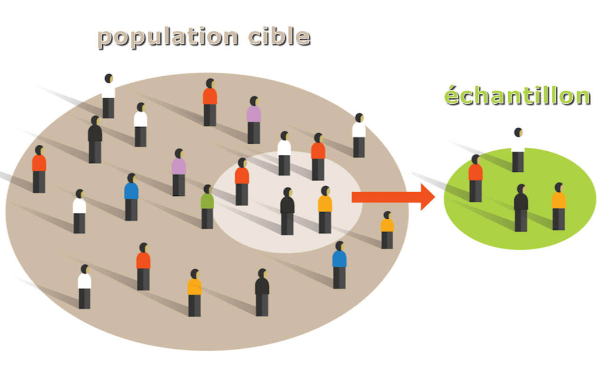

*Echantillonnage*

**Quel est l’âge moyen des français ?** C’est la première question à laquelle il vous sera demander d’apporter une réponse statistique. Plutôt que de vous envoyer interroger au hasard des centaines d’individus dans la rue ou par téléphone, nous avons choisi de vous faire travailler à partir d’une base de données reconstruites sur la base de statistique de l’INSEE. Cette base contient une très large population (500 000 individus) et il serait plus efficace, du point de vue de la qualité des résultats, d’utiliser toute la base. **Mais ce n’est pas le but. Ce projet se fixe pour objectif la mise en oeuvre de sondage et l’étude de la qualité des sondages effectués. Cela nécessite de considérer que l’on a un accès partiel à la base de donnée: l’échantillon tiré .**

Notez qu’il est très pratique de posséder l’intégralité des données de la population cible (ici, les 500 000 individus de la base de données). Les estimations faîtes sur la base de l’échantillon tiré peuvent être comparer avec les vrais paramètres de la population.

## 2.1 Génération d’échantillons

Créer une fonction `echantillonnage` permettant d’extraire de la base de données des échantillons de la taille que l’on souhaite. Les tirages aléatoires pour constituer ces échantillons doivent être **uniformes et indépendants**.

La fonction `echantillonnage` prendra en paramètres d’entrée la longeur des colonnes du data frame et la taille de l’échantillon que l’on souhaite extraire de cette population. Elle renverra un vecteur contenant les numéros de ligne à sélectionner dans le data frame pour créer l’échantillon.

```r
echantillonnage <- function(line_dataframe, size) {
  sample_indices <- sample(1:line_dataframe, size, replace = FALSE)
  return(sample_indices)
}
```

Voici un exmple de l’utilisation de la fonction `echantillonnage` pour tirer un échantillon de 10 individus dans la population.

```r
echantillonnage(nrow(population), 10)
```

```
## Indices tirés au hasard :
##  209321 109449 393121 169166 449716 354233 451857 294852 257335 254749
```

## 2.2 Estimations ponctuelles

1. Proposer un estimation ponctuelle de l’âge des français sur la base d’un échantilllon de 100 individus.

```
## ============================================================
##                  STATISTIQUE : MOYENNE D’ÂGE
## ============================================================
## Âge moyen observé dans l’échantillon   :  39.36ans
## ============================================================
```

Ce résultat indique que l’âge moyen des individus dans l’échantillon est de 39,36 ans. Cela donne une première idée de la tendance centrale de la variable « âge ».

2. Donner une estimation ponctuelle non biaisée de la variance de l’âge des français.

Rappel :

$$S_n^{2c}=\frac{1}{N-1}\sum_{i=1}^{n}(X_i
- \overline{X_n})^2$$

```
## ============================================================
##                  STATISTIQUE : VARIANCE DE L'ÂGE
## ============================================================
## Vraie variance de la population :  557.7
## ============================================================
```

```
## ============================================================
##                  STATISTIQUE : VARIANCE DE L'ÂGE
## ============================================================
## Variance estimé de l'échantillon :  577.75
## ============================================================
```

La variance observée de l’âge dans l’échantillon est de 577,75. Cela signifie que les âges sont assez dispersés autour de la moyenne. Une variance élevée indique une grande variabilité entre les individus : certains sont bien plus jeunes ou bien plus âgés que la moyenne (39,36 ans).

3. Créer deux data frame contenant respectivement que les hommes et que les femmes. Puis, sur la base d’échantillons de taille 100, proposer une estimation ponctuelle de l’âge moyen des hommes, puis de celui des femmes.

```
## ============================================================
##                  MOYENNE D'ÂGE PAR SEXE
## ============================================================
## Âge moyen observé - Femmes  : 43.99 ans
## Âge moyen observé - Hommes  : 43.5 ans
## ============================================================
```

Les résultats montrent que l’âge moyen des femmes est de 43,99 ans, tandis que celui des hommes est de 43,5 ans. La différence entre les deux moyennes est donc faible, de l’ordre de 0,5 an, ce qui suggère que la répartition de l’âge est assez similaire entre les sexes dans l’échantillon. Cette proximité indique qu’il n’y a pas de déséquilibre important en termes d’âge moyen entre les femmes et les hommes.

4. À l’aide d’une boucle `for`, tirez 500 échantillons de taille 25 dans la population cible des femmes et enregistrer l’estimation ponctuelle de l’âge dans le vecteur vec_result. Afficher l’histogramme de ces estimations. Même chose pour des échantillons de taille 100. On commentera les différences et ressemblances entre les deux histogrammes.

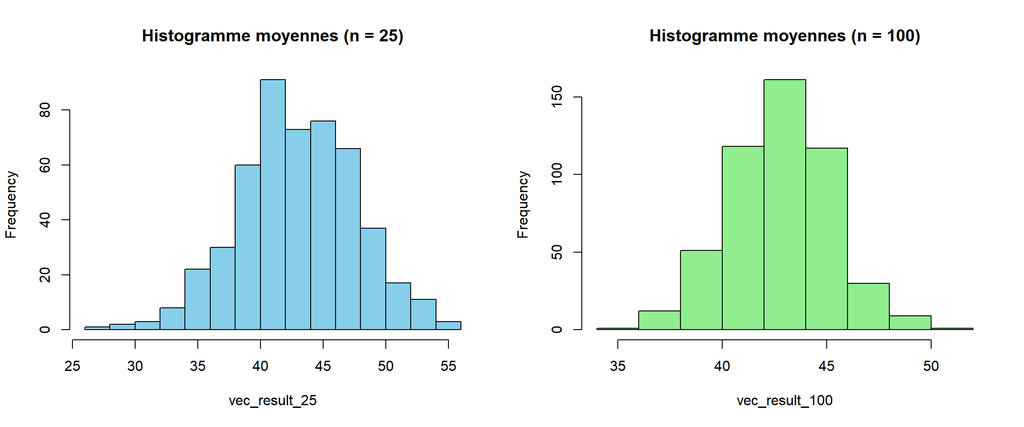

Les deux histogrammes montrent la distribution des moyennes d’âge chez les femmes pour des échantillons de tailles différentes. Quand la taille est de 25, les moyennes sont plus dispersées et varient davantage. Avec une taille de 100, les moyennes sont plus regroupées autour de la valeur centrale. Cela montre que plus la taille de l’échantillon augmente, plus les moyennes sont stables et proches de la vraie moyenne.

## 2.3 Estimations par intervalles de confiance

**Attention:** Dans cette partie, chaque fonction proposant un nouvel intervalle de confiance sera introduite par une phrase énoncant *le type de loi* choisie (normale ou student) avec son ou ses paramètres, et **l’ordre du quantile** à utiliser pour un intervalle de confiance de niveau 95%.

1. Créer une fonction fournissant un intervalle de confiance pour chacune des estimations ponctuelles du paragraphe précédent (2.2). Le niveau de confiance `conf_level` pourra être choisi par l’utilisateur (paramètre de la fonction). L’intervalle sera centré sur l’estimation ponctuelle. **Pour cette question, vous vous poserez notamment les questions suivantes: la variance de la caractéristique étudiée est-elle connue ou estimée? Quels quantiles interviennent dans la définition de l’intervalle de confiance ? Il existe en fait une fonction R prédéfinie qui calcule directement de tels intervalles de confiance. Vous pourrez l’utiliser pour vérifier vos résultats mais vous devrez dans tous les cas écrire par vous même un code R faisant ce travail.**

```r
IC <- function(echantillon, conf_level) {
  n <- length(echantillon)
  moy <- mean(echantillon)
  ecart_type <- sd(echantillon)
  alpha <- 1 - conf_level
  ddl <- n - 1
  t <- qt(1 - alpha / 2, df = ddl)
  erreur_marge <- t * ecart_type / sqrt(n)
  borne_inf <- moy - erreur_marge
  borne_sup <- moy + erreur_marge

  return(c(borne_inf, borne_sup))
}
```

```
## >>> IC via notre fonction :
```

```
## ============================================================
##            INTERVALLE DE CONFIANCE
##        (Variance inconnue — loi de Student)
## ============================================================
## Taille de l'échantillon        : n = 100
## Moyenne de l'échantillon       : 43.5
## Écart-type de l'échantillon    : 23.33
## Degrés de liberté (ddl)        : 99
## Quantile t (1 - α/2)           : 1.984
## Niveau de confiance            : 95 %
## -> Intervalle de confiance     : [38.87 ; 48.13]
## ============================================================
```

```
## Le vrai intervalle de confiance est : [ 38.87 , 48.13 ]
```

La moyenne d’âge observée dans l’échantillon est de 43,5 ans. L’intervalle de confiance à 95 % est [38,87 ; 48,13], ce qui signifie qu’on peut être confiant à 95 % que la moyenne réelle de l’âge dans la population se situe dans cette plage. L’intervalle reste assez large, ce qui reflète une certaine variabilité des âges dans l’échantillon.

2. Comment la longueur de l’intervalle de confiance varie-t-elle quand on change le niveau de confiance ? Même question quand la taille de l’échantillon augmente.

Comment la longueur de l’intervalle de confiance varie-t-elle quand on change le niveau de confiance ? Même question quand la taille de l’échantillon augmente.

**VARIATIONS DU NIVEAU DE CONFIANCE**

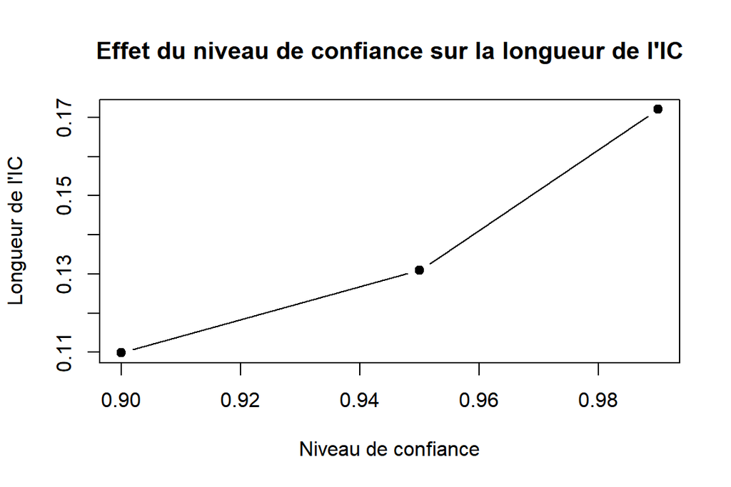

Ce graphique montre comment la longueur de l’intervalle de confiance (IC) évolue en fonction du niveau de confiance.

On observe que plus le niveau de confiance augmente, plus l’intervalle s’allonge. Cela s’explique par le fait qu’en voulant être plus sûr de contenir la vraie valeur, on accepte une marge d’incertitude plus grande. Par exemple, un IC à 99 % est plus long qu’un IC à 90 %, car il doit couvrir plus de cas possibles.

⇒ En résumé, il y a un compromis : plus le niveau de confiance est élevé, plus l’intervalle devient large. Cela confirme le comportement attendu des IC dans les statistiques.

**VARIATIONS DE LA TAILLE DE L’ÉCHANTILLON**

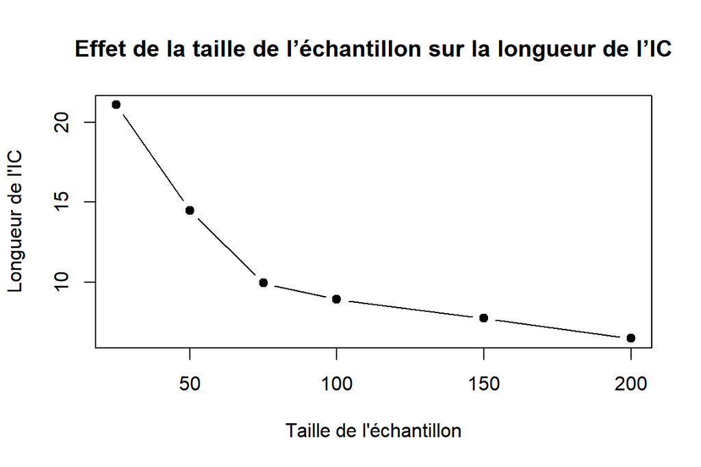

Ce graphique montre l’effet de la taille de l’échantillon sur la longueur de l’intervalle de confiance (IC).

On observe que lorsque la taille de l’échantillon augmente, la longueur de l’IC diminue rapidement. Cela signifie que plus on prend un grand échantillon, plus l’estimation devient précise, car la marge d’erreur diminue.

L’effet est particulièrement marqué entre les petites tailles (ex : 25 à 100), puis la diminution devient plus progressive à partir de 100. Cela reflète le fait que l’amélioration en précision est plus rapide au début, mais qu’il faut des échantillons de plus en plus grands pour continuer à raccourcir l’intervalle.

⇒ En résumé, plus l’échantillon est grand, plus l’IC est court, ce qui est cohérent avec les propriétés des statistiques d’échantillonnage.

3. Un intervalle de confiance pour une moyenne n’est pas nécessairement centré sur la moyenne d’échantillon $\overline{X}_n$; par exemple s’il est important de ne pas sous-estimer la moyenne, on peut préférer un intervalle de confiance borné seulement à gauche, c’est à dire de la forme $[a;+\infty[$. Créer une nouvelle fonction qui renvoit un intervalle de confiance de la forme $[a;+\infty[$ et un autre de la forme $]-\infty;b]$ pour l’âge moyen des français. **Vous veillerez à choisir convenablement les quantiles pour construire de tels intervalles de confiance.**

Jusqu’ici, les intervalles de confiance que nous avons construits pour estimer la moyenne de l’âge des Français étaient bilatéraux, c’est-à-dire symétriques autour de la moyenne observée de l’échantillon. Ce type d’intervalle vise à encadrer la vraie moyenne avec une marge d’erreur de part et d’autre.

Toutefois, dans certains contextes pratiques, il peut être plus pertinent de construire des intervalles de confiance unilatéraux, qui ne fournissent qu’une borne inférieure ou une borne supérieure à la moyenne, selon ce que l’on cherche à garantir.

Par exemple :

- Si l’objectif est d’éviter de sous-estimer la vraie moyenne, on construit un intervalle unilatéral inférieur de la forme [ a ; +∞[.
- Si, au contraire, on veut éviter de surestimer la moyenne, on construit un intervalle unilatéral supérieur de la forme ]−∞ ; b ].

Ces intervalles sont toujours fondés sur la loi de Student (quand la variance est inconnue), mais ne sont pas centrés sur la moyenne observée : ils s’écartent uniquement dans une direction, selon l’incertitude qu’on cherche à contrôler.

```r
IC_inf <- function(echantillon, conf_level = 0.95) {
  n <- length(echantillon)
  moy <- mean(echantillon)
  ecart_type <- sd(echantillon)
  ddl <- n - 1
  t <- qt(conf_level, df = ddl)
  borne_inf <- moy - t * ecart_type / sqrt(n)

  return(c(borne_inf, Inf))
}
```

```r
IC_sup <- function(echantillon, conf_level = 0.95) {
  n <- length(echantillon)
  moy <- mean(echantillon)
  ecart_type <- sd(echantillon)
  ddl <- n - 1
  t <- qt(conf_level, df = ddl)
  borne_sup <- moy + t * ecart_type / sqrt(n)

  return(c(-Inf, borne_sup))
}
```

```
## ============================================================
##    INTERVALLE DE CONFIANCE UNILATÉRAL INFÉRIEUR
##        (Variance inconnue — loi de Student)
## ============================================================
## Taille de l'échantillon        : n = 100
## Moyenne de l'échantillon       : 39.36
## Écart-type de l'échantillon    : 24.04
## Degrés de liberté (ddl)        : 99
## Quantile t (1 - α)             : 1.66
## Niveau de confiance            : 95 %
## -> Intervalle de confiance     : [35.37 ; +∞[
## ============================================================
```

```
## ============================================================
##    INTERVALLE DE CONFIANCE UNILATÉRAL SUPÉRIEUR
##        (Variance inconnue — loi de Student)
## ============================================================
## Taille de l'échantillon        : n = 100
## Moyenne de l'échantillon       : 39.36
## Écart-type de l'échantillon    : 24.04
## Degrés de liberté (ddl)        : 99
## Quantile t (1 - α)             : 1.66
## Niveau de confiance            : 95 %
## -> Intervalle de confiance     : ]−∞ ; 43.35]
## ============================================================
```

Dans notre cas, l’intervalle unilatéral inférieur $[35.37 ; +∞[$ permet d’affirmer, avec 95 % de confiance, que la vraie moyenne d’âge est au moins égale à 35.37 ans.  
L’intervalle supérieur $\ ]−∞ ; 43.35]$, quant à lui, indique que cette moyenne est au plus égale à 43.35 ans.

Ces deux résultats reposent sur un échantillon de 100 individus, une moyenne observée de 39.36 ans, et un écart-type estimé de 24.04.

Le quantile $t$ utilisé (1.66) provient de la loi de Student avec 99 degrés de liberté, car la variance de la population est inconnue.  
Ces intervalles illustrent bien comment, à partir des mêmes données, on peut obtenir deux bornes différentes selon la direction dans laquelle on souhaite encadrer la moyenne.

## 2.4 Etude de la qualité des sondages

Dans cette partie, on cherche à étudier la qualité des marges d’erreurs des intervalles de confiance.

Protocole: (1) générer un grand nombre d’échantillons de même taille, (2) déterminer les intervalles de confiance associés aux échantillons tirés ($\alpha$ est fixe), (3) calculer la proportion des intervalles de confiance obtenus qui contiennent la vraie valeur (celle de la population).

- De quelle valeur théorique devrait s’approcher la proportion des intervalles de confiance contenant la vraie moyenne ?
- Créer le code permettant de réaliser le protocole ci-dessus.
- Faire varier la caractéristique à étudier, la taille de l’échantillon, le niveau de confiance … et commentez les résultats.

**1) Génération de 1000 échantillons et 2) Calculs des intervalles de confiance**

La proportion des intervalles de confiance contenant la vraie moyenne devrait, en théorie, être proche du niveau de confiance choisi. Cela signifie que si l’on construit des intervalles à 95 %, environ 95 % de ces intervalles doivent contenir la vraie valeur de la moyenne. De la même manière, pour un niveau de confiance de 90 %, on s’attend à ce qu’environ 90 % des intervalles construits incluent la moyenne réelle. Cette proportion correspond donc à la probabilité théorique 1-𝛼, définie à l’avance lors de la construction des intervalles.

```
## ——— IC Simulation ———
## Taille échantillon (n) : 30  | Niveau de confiance : 90 % | Nombre de répétitions (B) : 1000
## Proportion des IC contenant la vraie moyenne : 0.899
## ✔ Résultat cohérent
##
## ——— IC Simulation ———
## Taille échantillon (n) : 30  | Niveau de confiance : 95 % | Nombre de répétitions (B) : 1000
## Proportion des IC contenant la vraie moyenne : 0.939
## ⚠ Écart notable — à analyser
##
## ——— IC Simulation ———
## Taille échantillon (n) : 30  | Niveau de confiance : 99 % | Nombre de répétitions (B) : 1000
## Proportion des IC contenant la vraie moyenne : 0.986
## ✔ Résultat cohérent
##
## -----------------------------------------------------
##
## ——— IC Simulation ———
## Taille échantillon (n) : 50  | Niveau de confiance : 90 % | Nombre de répétitions (B) : 1000
## Proportion des IC contenant la vraie moyenne : 0.896
## ✔ Résultat cohérent
##
## ——— IC Simulation ———
## Taille échantillon (n) : 50  | Niveau de confiance : 95 % | Nombre de répétitions (B) : 1000
## Proportion des IC contenant la vraie moyenne : 0.952
## ✔ Résultat cohérent
##
## ——— IC Simulation ———
## Taille échantillon (n) : 50  | Niveau de confiance : 99 % | Nombre de répétitions (B) : 1000
## Proportion des IC contenant la vraie moyenne : 0.991
## ✔ Résultat cohérent
##
## -----------------------------------------------------
##
## ——— IC Simulation ———
## Taille échantillon (n) : 100  | Niveau de confiance : 90 % | Nombre de répétitions (B) : 1000
## Proportion des IC contenant la vraie moyenne : 0.905
## ✔ Résultat cohérent
##
## ——— IC Simulation ———
## Taille échantillon (n) : 100  | Niveau de confiance : 95 % | Nombre de répétitions (B) : 1000
## Proportion des IC contenant la vraie moyenne : 0.947
## ✔ Résultat cohérent
##
## ——— IC Simulation ———
## Taille échantillon (n) : 100  | Niveau de confiance : 99 % | Nombre de répétitions (B) : 1000
## Proportion des IC contenant la vraie moyenne : 0.989
## ✔ Résultat cohérent
##
## -----------------------------------------------------
```

Les simulations montrent que la proportion d’intervalles de confiance (IC) contenant la vraie moyenne est globalement cohérente avec le niveau de confiance théorique attendu, surtout lorsque la taille de l’échantillon augmente.

Pour un échantillon de 30 individus, on observe un léger écart à 95% de confiance (0.939 au lieu de 0.95), signalé comme notable. Cet écart peut s’expliquer par la variabilité plus forte des petits échantillons, et par le fait que la loi de Student, bien qu’adaptée, reste une approximation. Cela montre qu’avec un effectif réduit, la couverture réelle peut être inférieure au niveau théorique.

En revanche, pour les niveaux de confiance à 90% et 99%, les proportions observées sont proches des valeurs attendues (0.899 et 0.986), ce qui reste acceptable statistiquement.

Lorsque la taille de l’échantillon passe à 50, puis à 100, la stabilité s’améliore : les proportions d’IC contenant la vraie moyenne sont alors très proches des niveaux de confiance spécifiés, voire légèrement supérieures. Cela confirme que plus la taille de l’échantillon est grande, plus les IC sont fiables, et leur fréquence de couverture se rapproche du niveau théorique.

**En résumé** :

- Les niveaux de confiance élevés (99%) sont bien respectés, quel que soit $n$
- Pour des tailles modestes ($n = 30$), un petit écart peut apparaître à 95%
- Une augmentation de la taille d’échantillon améliore la précision et la robustesse des IC

## 2.5 Y a-t-il plus d’hommes ou de femmes dans la population française ?

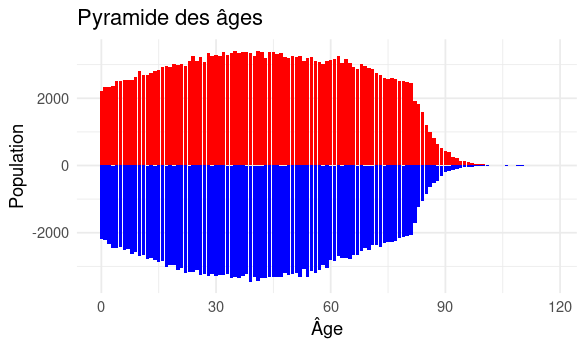

*Pyramide des âges (données “population”)*

Pour étudier ce problème, il faut utiliser le théorème suivant.

**Théorème:** Soit $\overline{X}_n$ la moyenne empirique d’un $n$-échantillon de loi de Bernoulli $\mathcal{B}(p).$ On a:
$$\dfrac{\sqrt{n} (\overline{X}_n-p)}{\sqrt{p(1-p)}}\underset{n\rightarrow
+\infty}{\overset{\mathcal{L}}\rightarrow} N(0,1)$$
Cela signifie que pour $n$ suffisamment grand ($n>100$), il est raisonnable d’approcher la distribution de la v.a. $\sqrt{\frac{n}{p(1-p)}}(\overline{X}_n-p)$ par une loi normale centrée réduite.

1. Servez-vous de ce théorème pour déterminer un intervalle de confiance de la probabilité qu’une personne soit de sexe masculin en prenant comme échantillon l’intégralité du data frame (les 500 000 individus). Faîtes varier le niveau de confiance: $\alpha=0.95, 0.99, 0.999 ...$ Quelles sont vos conclusions ?

### Construction d’un intervalle de confiance pour une proportion

Dans cette question, nous cherchons à construire des intervalles de confiance pour une proportion, en l’occurrence celle des hommes dans la population.

Le choix de la loi normale centrée réduite $\mathcal{N}(0, 1)$ est justifié par la taille suffisamment grande de l’échantillon. Cette loi est définie par deux paramètres :

- une moyenne $\mu = 0$,
- un écart-type $\sigma = 1$.

L’intervalle de confiance est construit à partir de la proportion observée $\hat{p}$, et s’appuie sur le quantile $z_{1 - \alpha/2}$ de la loi normale, où $\alpha$ est le risque d’erreur ($\alpha = 1 - \text{niveau de confiance}$).

Le quantile utilisé dépend donc du niveau de confiance :

- Pour 95% de confiance ($\alpha = 0,05$) : $z_{0,975} \approx 1{,}960$
- Pour 99% ($\alpha = 0,01$) : $z_{0,995} \approx 2,576$
- Pour 99,9% ($\alpha = 0,001$) : $z_{0,9995} \approx 3,291$

La formule de l’intervalle de confiance s’écrit :

$$IC = \left[ \hat{p} - z_{1 - \alpha/2} \cdot \sqrt{\frac{\hat{p}(1 -
\hat{p})}{n}} \ ;\ \hat{p} + z_{1 - \alpha/2} \cdot
\sqrt{\frac{\hat{p}(1 - \hat{p})}{n}} \right]$$

où :

- $\hat{p}$ est la proportion observée (nombre d’hommes divisé par $n$),
- $n$ est la taille de l’échantillon,
- $z_{1 - \alpha/2}$ est le quantile de la loi normale associé au niveau de confiance.

L’objectif est d’évaluer, pour plusieurs niveaux de confiance (95 %, 99 %, 99.9 %), les bornes dans lesquelles se situe la vraie proportion d’hommes dans la population.

```r
# Fonction pour calculer l'IC avec la loi normale
calcul_IC <- function(p_hat, n, alpha) {
  z <- qnorm(1 - alpha / 2)
  erreur <- z * sqrt(p_hat * (1 - p_hat) / n)
  borne_inf <- p_hat - erreur
  borne_sup <- p_hat + erreur
  return(c(borne_inf, borne_sup))
}
```

```
## ============================================================
##          ÉTUDE DE L'IC POUR UNE PROPORTION
## ============================================================
## Taille de l'échantillon        : n = 500000
## Niveau de confiance théorique  : 95 %
## Proportion observée (p̂)        : 0.4879
## Intervalle de confiance         : [0.4865 ; 0.4893]
## Quantile utilisé (z)            : 1.96
## ============================================================
##
## ============================================================
##          ÉTUDE DE L'IC POUR UNE PROPORTION
## ============================================================
## Taille de l'échantillon        : n = 500000
## Niveau de confiance théorique  : 99 %
## Proportion observée (p̂)        : 0.4879
## Intervalle de confiance         : [0.4861 ; 0.4897]
## Quantile utilisé (z)            : 2.576
## ============================================================
##
## ============================================================
##          ÉTUDE DE L'IC POUR UNE PROPORTION
## ============================================================
## Taille de l'échantillon        : n = 500000
## Niveau de confiance théorique  : 99.9 %
## Proportion observée (p̂)        : 0.4879
## Intervalle de confiance         : [0.4856 ; 0.4902]
## Quantile utilisé (z)            : 3.291
## ============================================================
```

Les résultats confirment que plus le niveau de confiance augmente, plus l’intervalle de confiance s’élargit. Cela s’explique par le fait que pour être plus certain d’inclure la vraie proportion dans l’intervalle, il faut accroître la marge d’erreur.

Ici, la proportion observée d’hommes dans la population est de 0.4879, et la taille de l’échantillon est très grande (500 000 individus). Grâce à cette taille importante, les intervalles restent très serrés, même avec un niveau de confiance élevé.

Par exemple :

- à 95%, l’intervalle est $[0.4865 ; 0.4893]$,
- à 99%, il devient $[0.4861 ; 0.4897]$,
- et à 99.9%, il s’élargit légèrement à $[0.4856 ; 0.4902]$.

Ces résultats montrent que l’estimation de la proportion est très précise, quel que soit le niveau de confiance choisi. La loi normale centrée réduite utilisée ici, avec son quantile adapté à chaque niveau ($z = 1.96$, $2.576$, ou $3.291$), permet donc de construire des intervalles fiables, d’autant plus que l’échantillon est grand.

2. Quelle devrait être la taille de l’échantillon tiré parmi les 500 000 français pour que l’intervalle de confiance au niveau 95% de la probabilité qu’un individu soit de sexe masculin ait une longueur inférieur ou égale à 1%. Dans cette question, on utilisera tour à tour une majoration de la variance, puis la variance estimée à l’aide des données (on parle de la variance des variables aléatoires de loi de Bernoulli $\mathcal{B}(p)$).

```r
# Niveau de confiance
alpha <- 0.05
z <- qnorm(1 - alpha / 2)
longueur_max <- 0.01

# Méthode 1 : majoration de la variance (p(1 - p) <= 0.25)
variance_max <- 0.25
n_majoration <- (z^2 * variance_max) / (longueur_max / 2)^2

# Méthode 2 : variance estimée à partir des données
sexe <- population$SEXE
n_total <- length(sexe)
p_hat <- sum(sexe == "H") / n_total
variance_estimee <- p_hat * (1 - p_hat)
```

```
## ============================================================
##    CALCUL DE LA TAILLE MINIMALE DE L'ÉCHANTILLON
## ============================================================
## Niveau de confiance               : 95 %
## Longueur maximale de l'IC         : 0.01
## Quantile utilisé (z)              : 1.96
##
## Méthode 1 : Majorant p(1 - p) <= 0.25
## Taille minimale estimée           : n ≥ 38415
##
## Méthode 2 : Variance estimée à partir des données
## Proportion observée (p̂)           : 0.4879
## Variance estimée                  : 0.2499
## Taille minimale estimée           : n ≥ 38393
## ============================================================
```

L’objectif ici est de déterminer la taille minimale d’un échantillon à extraire de la population pour que l’intervalle de confiance à 95% de la proportion d’hommes ait une longueur inférieure ou égale à 1%, soit une amplitude maximale de 0.01.

Deux méthodes ont été utilisées pour ce calcul.

La première méthode repose sur une majoration de la variance : on utilise le fait que pour une variable de Bernoulli, la variance maximale $p(1 - p)$ est atteinte lorsque $p = 0.5$, ce qui donne une valeur maximale de 0.25. Cette approche ne nécessite pas d’estimation préalable, mais donne une valeur légèrement prudente. Elle conduit à une taille minimale estimée de 38 415 individus.

La deuxième méthode utilise la variance empirique estimée à partir de la proportion observée $\hat{p} = 0.4879$, ce qui donne une variance de $\hat{p}(1 - \hat{p}) = 0.2499$, très proche de 0.25. Cette méthode, plus précise puisqu’elle repose sur les données, donne une taille minimale légèrement inférieure, soit 38 393 individus.

Dans les deux cas, on utilise le quantile $z_{0.975} = 1.96$ de la loi normale, correspondant à un niveau de confiance de 95 %.

Ces résultats montrent qu’avec une population de 500 000 personnes, il est possible de tirer un échantillon d’environ 38 400 individus pour obtenir une estimation de la proportion d’hommes avec une précision de ±0.5%, ce qui est statistiquement très fiable.

## 2.6 Le lien entre l’âge et le niveau d’étude

Cette partie est la plus libre. Elle constitue une part essentielle du travail à réaliser et sera évaluer en conséquence. L’intégralité de ce qui a été vue précédement peut-être réinvesti, l’objectif étant d’illustrer le lien qui existe entre niveau d’étude et âge.

Pour cela, vous tirerez des échantillons de tailles respectives 25, 100 et 500 dans des populations cibles choisies par vos soins. Et pour chacun de ces échantillons, vous proposerez un ou des intervalle(s) de confiance que vous commenterez. Le commentaire incluera autant la validité du calcul fait (respect des hypothèses: quelle est la loi utilisée et pourquoi) que les conséquences pratiques de ces résultats.

### Introduction : lien entre âge et niveau d’étude

Dans cette dernière partie, nous cherchons à illustrer l’existence d’un lien entre le niveau d’étude et l’âge dans la population française étudiée.  
Pour cela, nous construisons d’abord des intervalles de confiance sur des échantillons de différentes tailles, puis nous menons plusieurs analyses statistiques globales (test du Chi², test de proportions, régression logistique) afin de vérifier statistiquement l’existence de ce lien.

L’objectif est à la fois d’observer les effets de la taille de l’échantillon sur la précision des estimations, et de valider ou non l’existence d’un lien significatif entre l’âge et le fait d’avoir un Bac ou plus.

```
## ============================================================
## ÉCHANTILLON de taille : 25
## Tranche : 15-30
##  - Proportion Bac+ : 1
##  - IC unilatéral sup. (95%) : 1 à 1
## Tranche : 31-50
##  - Proportion Bac+ : 0.4
##  - IC unilatéral sup. (95%) : 0.4 à 0.6548
## Tranche : 51-100
##  - Proportion Bac+ : 0.3077
##  - IC unilatéral sup. (95%) : 0.3077 à 0.5182
## ============================================================
##
## ============================================================
## ÉCHANTILLON de taille : 100
## Tranche : 15-30
##  - Proportion Bac+ : 0.8421
##  - IC unilatéral sup. (95%) : 0.8421 à 0.9797
## Tranche : 31-50
##  - Proportion Bac+ : 0.8333
##  - IC unilatéral sup. (95%) : 0.8333 à 0.9355
## Tranche : 51-100
##  - Proportion Bac+ : 0.3333
##  - IC unilatéral sup. (95%) : 0.3333 à 0.4489
## ============================================================
##
## ============================================================
## ÉCHANTILLON de taille : 500
## Tranche : 15-30
##  - Proportion Bac+ : 0.9103
##  - IC unilatéral sup. (95%) : 0.9103 à 0.9635
## Tranche : 31-50
##  - Proportion Bac+ : 0.633
##  - IC unilatéral sup. (95%) : 0.633 à 0.6908
## Tranche : 51-100
##  - Proportion Bac+ : 0.4145
##  - IC unilatéral sup. (95%) : 0.4145 à 0.4675
## ============================================================
```

### Analyse des intervalles de confiance

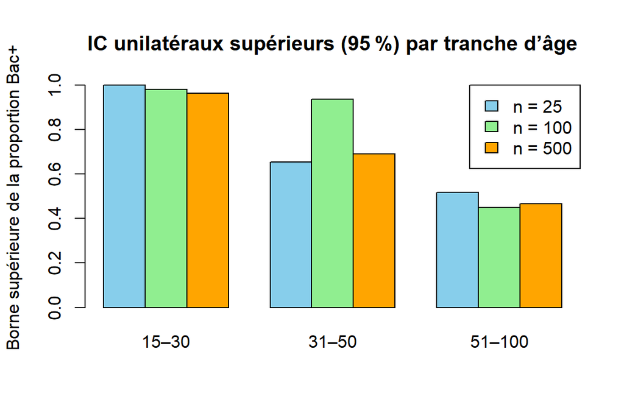

Les résultats montrent que :

- les proportions de Bac+ sont plus élevées chez les jeunes (15–30 ans) que chez les plus âgés,
- les IC deviennent plus précis à mesure que la taille de l’échantillon augmente,
- les petits échantillons (n = 25) donnent des estimations beaucoup plus incertaines, parfois peu fiables,
- les grands échantillons (n = 500) permettent des estimations robustes, avec une faible marge d’erreur.

### Test du Chi² d’indépendance

Nous avons réalisé un test du Chi² pour déterminer s’il existe un lien statistique entre la tranche d’âge (15–30, 31–50, 51–100 ans) et le fait d’avoir un niveau Bac ou plus.

> Hypothèses :
> - H₀ : l’âge et le niveau d’étude sont indépendants.
> - H₁ : il existe une dépendance entre les deux variables.

```
##
##           FALSE   TRUE
##   15-30   14883  54860
##   31-50   46459  86086
##   51-100 119190  72807
```

```
##
## Test du Chi² d'indépendance
```

```
##
##  Pearson's Chi-squared test
##
## data:  tab_chi2
## X-squared = 43477, df = 2, p-value < 2.2e-16
```

Le test donne une p-valeur très faible (p < 0.001), ce qui nous conduit à rejeter l’hypothèse d’indépendance.

Conclusion : l’âge est statistiquement lié au niveau d’étude : la probabilité d’avoir un Bac+ varie significativement selon la tranche d’âge.

### Comparaison de proportions

Nous avons comparé la proportion de personnes ayant un Bac+ parmi les 15–30 ans et les 51–100 ans à l’aide d’un test de proportion.

```
##
## Test de proportion : jeunes vs vieux
```

```
##
##  2-sample test for equality of proportions without continuity correction
##
## data:  c(nb_bacplus_jeunes, nb_bacplus_vieux) out of c(nb_jeunes, nb_vieux)
## X-squared = 33984, df = 1, p-value < 2.2e-16
## alternative hypothesis: two.sided
## 95 percent confidence interval:
##  0.4036574 0.4111289
## sample estimates:
##    prop 1    prop 2
## 0.7866022 0.3792091
```

> Résultat : la p-valeur obtenue est très faible (p < 0.001), ce qui indique que la différence observée n’est pas due au hasard.

La proportion de Bac+ est nettement plus élevée chez les jeunes que chez les personnes âgées. Cela traduit une élévation du niveau de formation dans les générations récentes.

Interprétation pratique : ce résultat peut s’expliquer par l’amélioration de l’accès aux études supérieures au fil des décennies.

### Modélisation logistique : effet de l’âge sur le niveau Bac+

Nous avons ajusté un modèle de régression logistique pour estimer la probabilité d’avoir un Bac+ en fonction de l’âge.

```
##
## Modèle logistique : Bac+ ~ âge
```

```
##
## Call:
## glm(formula = Bac_plus ~ AGE, family = "binomial", data = df)
##
## Coefficients:
##               Estimate Std. Error z value Pr(>|z|)
## (Intercept)  2.0824748  0.0103756   200.7   <2e-16 ***
## AGE         -0.0374409  0.0001908  -196.2   <2e-16 ***
## ---
## Signif. codes:  0 '***' 0.001 '**' 0.01 '*' 0.05 '.' 0.1 ' ' 1
##
## (Dispersion parameter for binomial family taken to be 1)
##
##     Null deviance: 543793  on 394284  degrees of freedom
## Residual deviance: 500903  on 394283  degrees of freedom
## AIC: 500907
##
## Number of Fisher Scoring iterations: 4
```

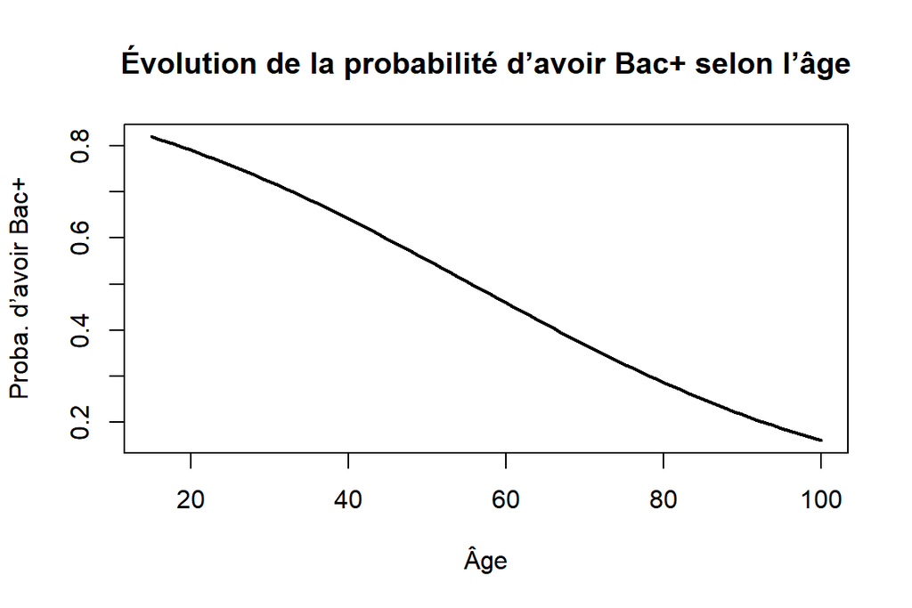

> Le modèle est significatif (p < 0.001 pour le coefficient de l’âge), avec un coefficient négatif.

Interprétation : plus l’âge augmente, moins la probabilité d’avoir un Bac+ est élevée. Cela confirme la tendance déjà observée visuellement et statistiquement.

Un graphique permet de visualiser cette relation : la courbe décroît régulièrement entre 20 et 80 ans.

Ce modèle permettrait par exemple de prédire la probabilité d’avoir un Bac+ pour une personne d’un âge donné.

### Conclusion générale

L’ensemble des résultats confirme l’existence d’un lien statistique fort entre l’âge et le niveau d’étude. Les jeunes générations sont significativement plus nombreuses à posséder un niveau Bac ou plus que les plus âgées, ce qui reflète l’évolution du système éducatif.

Les intervalles de confiance et les tests statistiques convergent dans le même sens : la proportion de Bac+ est clairement croissante à mesure qu’on descend en âge.

En complément, le modèle de régression logistique montre que la probabilité d’avoir un Bac+ diminue continuellement avec l’âge, ce qui peut être modélisé et visualisé précisément.

Ces résultats illustrent bien l’intérêt de croiser les méthodes statistiques exploratoires et confirmatoires, et montrent également l’importance de la taille de l’échantillon dans la fiabilité des estimations.